# Red Wine Quality Exploration by Karina Lund

Dataset I analyzed contains 1,599 red wines with 11 variables of the chemical properties of the wine. At least 3 wine experts rated the quality of each wine, providing a rating between 0 (very bad) and 10 (excellent).

“Which chemical properties influence the quality of red wines?” is the question I will try to find answer to.

# Univariate Plots Section

First 10 rows from dataset

```
##     X fixed.acidity volatile.acidity citric.acid residual.sugar chlorides
## 1   1           7.4             0.70        0.00            1.9     0.076
## 2   2           7.8             0.88        0.00            2.6     0.098
## 3   3           7.8             0.76        0.04            2.3     0.092
## 4   4          11.2             0.28        0.56            1.9     0.075
## 5   5           7.4             0.70        0.00            1.9     0.076
## 6   6           7.4             0.66        0.00            1.8     0.075
## 7   7           7.9             0.60        0.06            1.6     0.069
## 8   8           7.3             0.65        0.00            1.2     0.065
## 9   9           7.8             0.58        0.02            2.0     0.073
## 10 10           7.5             0.50        0.36            6.1     0.071
##    free.sulfur.dioxide total.sulfur.dioxide density   pH sulphates alcohol
## 1                   11                   34  0.9978 3.51      0.56     9.4
## 2                   25                   67  0.9968 3.20      0.68     9.8
## 3                   15                   54  0.9970 3.26      0.65     9.8
```

[output cut: 18 more lines]

Dimensions of the dataset

```
## [1] 1599   13
```

Dataset structure

```
## 'data.frame':    1599 obs. of  13 variables:
##  $ X                   : int  1 2 3 4 5 6 7 8 9 10 ...
##  $ fixed.acidity       : num  7.4 7.8 7.8 11.2 7.4 7.4 7.9 7.3 7.8 7.5 ...
##  $ volatile.acidity    : num  0.7 0.88 0.76 0.28 0.7 0.66 0.6 0.65 0.58 0.5 ...
##  $ citric.acid         : num  0 0 0.04 0.56 0 0 0.06 0 0.02 0.36 ...
##  $ residual.sugar      : num  1.9 2.6 2.3 1.9 1.9 1.8 1.6 1.2 2 6.1 ...
##  $ chlorides           : num  0.076 0.098 0.092 0.075 0.076 0.075 0.069 0.065 0.073 0.071 ...
##  $ free.sulfur.dioxide : num  11 25 15 17 11 13 15 15 9 17 ...
##  $ total.sulfur.dioxide: num  34 67 54 60 34 40 59 21 18 102 ...
##  $ density             : num  0.998 0.997 0.997 0.998 0.998 ...
##  $ pH                  : num  3.51 3.2 3.26 3.16 3.51 3.51 3.3 3.39 3.36 3.35 ...
##  $ sulphates           : num  0.56 0.68 0.65 0.58 0.56 0.56 0.46 0.47 0.57 0.8 ...
##  $ alcohol             : num  9.4 9.8 9.8 9.8 9.4 9.4 9.4 10 9.5 10.5 ...
##  $ quality             : int  5 5 5 6 5 5 5 7 7 5 ...
```

Dataset summary

```
##        X          fixed.acidity   volatile.acidity  citric.acid
##  Min.   :   1.0   Min.   : 4.60   Min.   :0.1200   Min.   :0.000
##  1st Qu.: 400.5   1st Qu.: 7.10   1st Qu.:0.3900   1st Qu.:0.090
##  Median : 800.0   Median : 7.90   Median :0.5200   Median :0.260
##  Mean   : 800.0   Mean   : 8.32   Mean   :0.5278   Mean   :0.271
##  3rd Qu.:1199.5   3rd Qu.: 9.20   3rd Qu.:0.6400   3rd Qu.:0.420
##  Max.   :1599.0   Max.   :15.90   Max.   :1.5800   Max.   :1.000
##  residual.sugar     chlorides       free.sulfur.dioxide
##  Min.   : 0.900   Min.   :0.01200   Min.   : 1.00
##  1st Qu.: 1.900   1st Qu.:0.07000   1st Qu.: 7.00
##  Median : 2.200   Median :0.07900   Median :14.00
##  Mean   : 2.539   Mean   :0.08747   Mean   :15.87
##  3rd Qu.: 2.600   3rd Qu.:0.09000   3rd Qu.:21.00
##  Max.   :15.500   Max.   :0.61100   Max.   :72.00
##  total.sulfur.dioxide    density             pH          sulphates
##  Min.   :  6.00       Min.   :0.9901   Min.   :2.740   Min.   :0.3300
##  1st Qu.: 22.00       1st Qu.:0.9956   1st Qu.:3.210   1st Qu.:0.5500
##  Median : 38.00       Median :0.9968   Median :3.310   Median :0.6200
##  Mean   : 46.47       Mean   :0.9967   Mean   :3.311   Mean   :0.6581
##  3rd Qu.: 62.00       3rd Qu.:0.9978   3rd Qu.:3.400   3rd Qu.:0.7300
##  Max.   :289.00       Max.   :1.0037   Max.   :4.010   Max.   :2.0000
##     alcohol         quality
##  Min.   : 8.40   Min.   :3.000
##  1st Qu.: 9.50   1st Qu.:5.000
##  Median :10.20   Median :6.000
##  Mean   :10.42   Mean   :5.636
##  3rd Qu.:11.10   3rd Qu.:6.000
##  Max.   :14.90   Max.   :8.000
```

## Univariate plots

### Acids

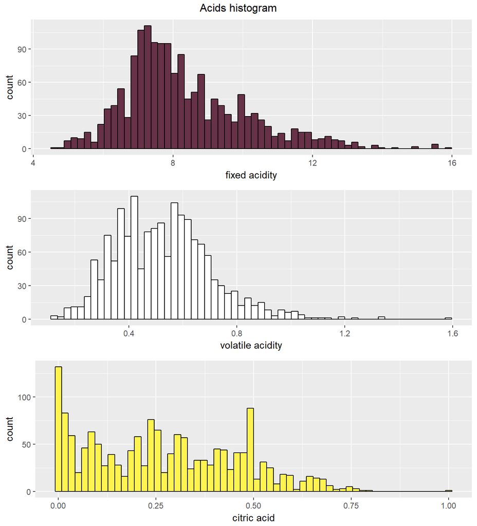

The principal organic acids found in grapes are tartaric and malic, to a small extent, citric and others. Tartaric acid (fixed acidity) and malic acid account for over 90% of the total acids present.

Fixed acidity in dataset has a range from 4.6 to 15.90 g/dm³, while volatile and citric acids have a range from 0.12 to 1.5 and 0 to 1 respectively.

Volatile acidity is responsible for the sour taste of vinegar. An excessive amount of acetic acid is also considered a wine fault.

### Sulfur dioxide

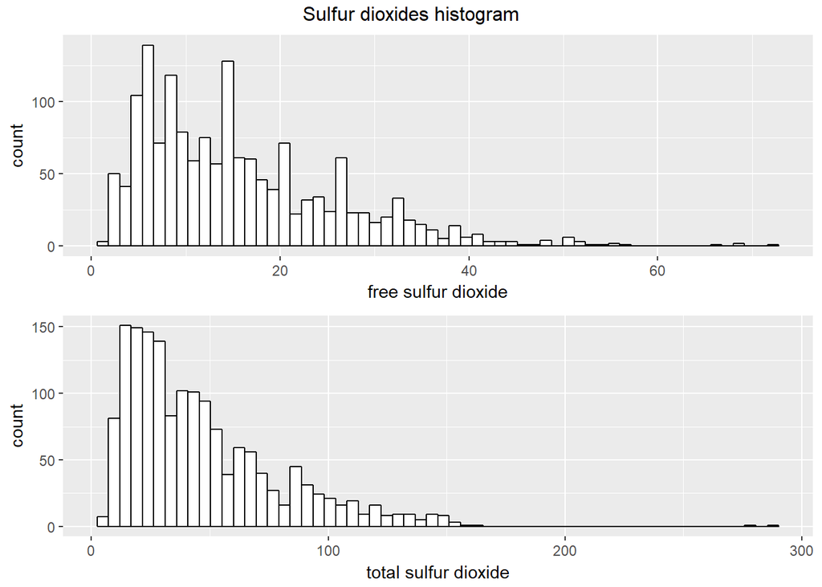

Sulfur dioxide serves as an antibiotic and antioxidant, protecting wine from spoilage by bacteria and oxidation. Its antimicrobial action also helps to minimize volatile acidity. The nose will be able to detect SO2 in wine in the range of 15-40 ppm or higher dosage. If wine contains too much sulphur, person can be able to taste it and that’s nasty taste.

There is no wine in dataset that are totally free for sulfur dioxide. Naturally occurring sulfites are generated in very small amounts ranging from 6 to 40 ppm. Most of wines in collection have a free sulfur dioxide under 21 mg/dm³ and a total sulfur dioxide under 62 mg/dm³. There are two wines that have a very high total sulfur dioxide compared to others.

Total SO2 = Free SO2 + Bound SO2.  
If the wine is bottle-aged, the SO2 will decrease as more sulfites react with other chemical constituents (sugars, acetaldehyde or phenolic compounds) in the wine and become bound. Bound sulfur dioxide can be 50 - 90% of the amount of SO2 added to wine. I will create a new variable for bound SO2.

### Sugar, chlorides, sulphates

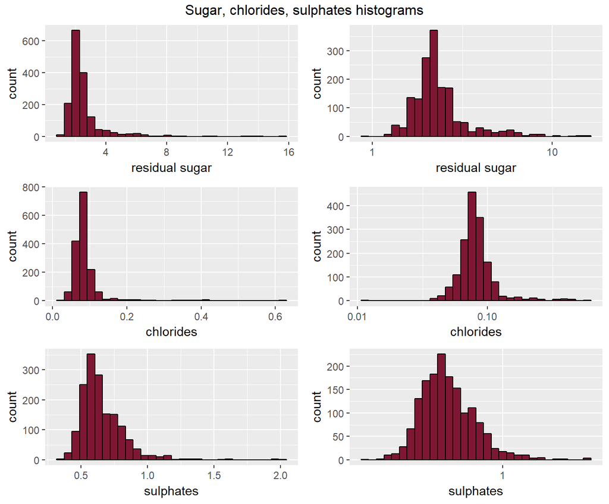

Residual Sugar is the level of glucose and fructose (grape sugars) that are not converted into alcohol during fermentation.

Sodium chloride shows amount of salt in the wine.

Potassium sulphate is a “wine stabilizer”. It has a bitter, salty taste.

Residual Sugar, chlorides and sulphates are right skewed, that’s why log10 transformation is used.

### Alcohol, density and pH

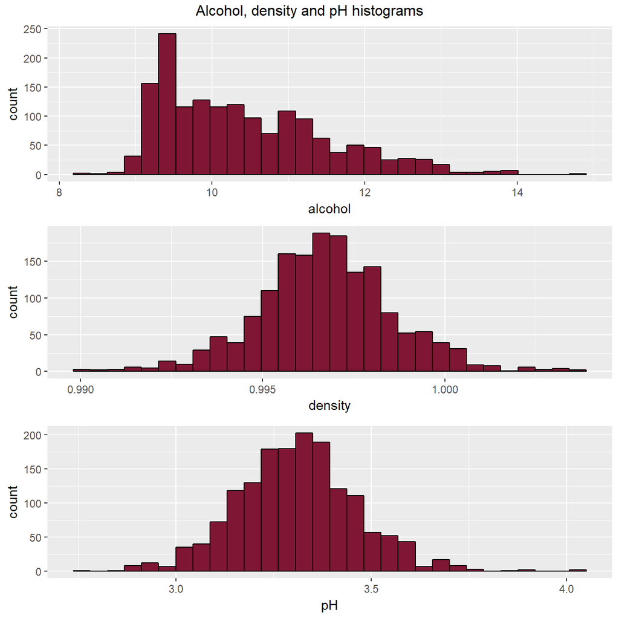

Alcohol directly correlates to the ripeness (sugar content) of grapes. As grapes ferment, the sugar converts to alcohol.

Density in wine is generally used as a measure of the conversion of sugar to alcohol.

Winemakers use pH as a way to measure ripeness in relation to acidity. Low pH wines will taste tart and crisp, while higher pH wines are more susceptible to bacterial growth. Most wine pH’s fall around 3 or 4. pH from 3.3 to 3.6 is best for red wines. Most wines in dataset has pH from 3.2 to 3.4.

Density and pH are distributed normally.

### Quality

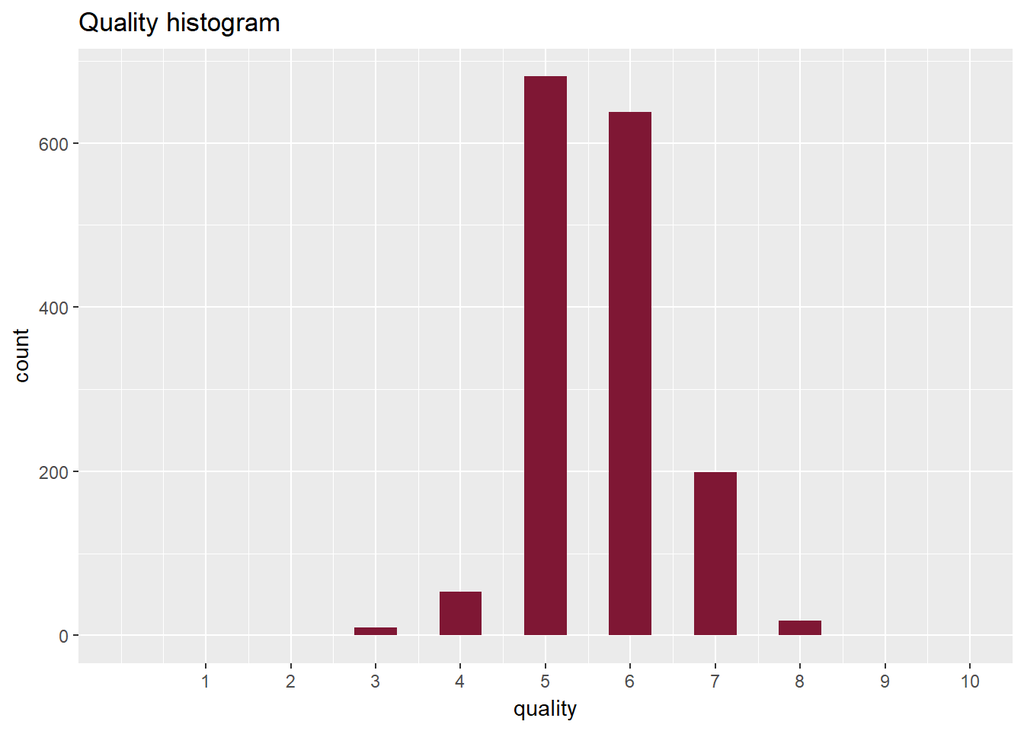

There is no wine, that have got worst or best scores. Most of tested wines have been rated by experts as average. I will create a new variable rating by cutting quality in groups of 2.

```r
redwine$rating<- cut(redwine$quality, breaks = c(0,2,4,6,8,10))
```

# Univariate Analysis

### What is the structure of your dataset?

Dataset contains 1599 red wines with 11 variables on the chemical properties of the wine, such as fixed acidity, volatile acidity, citric acid, residual sugar, sodium chloride, free and total sulfur dioxides, density, pH, sulphates and alcohol. Dataset also includes a quality rating of wine provided by experts. Dataset doesn’t contain any missing values. All columns are numerical.

### What is/are the main feature(s) of interest in your dataset?

I would like to determine which properties influence the quality of red wines most. The main feature of interest is quality.

### What other features in the dataset do you think will help support your investigation into your feature(s) of interest?

I can assume that acidity, alcohol and sugar influence the quality of red wine. Volatile acidity is responsible for the sour taste of vinegar. Citric acid gives a “fresh” flavor. Sugar gives sweetness. It also could be sulfur dioxide, because high level of it can be detected by nose. Or sulphate, because of bitter, salty taste.

### Of the features you investigated, were there any unusual distributions? Did you perform any operations on the data to tidy, adjust, or change the form of the data? If so, why did you do this?

I created 2 new variables:  
* bound SO2, which is difference between Total and Free SO2;  
* rating: for break quality in groups of 2.

Fixed and volatile acidity plots are right skewed, with some outliers with high amount of acids. Citric acid histogram has 3 peaks: 0, 0.25 and 0.5 g/dm³. Peak with 0 g/dm³ if citric acid is highest. That can be explain by a fact that some wines don’t contain any citric acid at all.

Free and total sulfur dioxide plots are right skewed too. Free sulfur dioxide distribution has some outliers for values from 66-72. And Total sulfur dioxide have 2 outliers for value near 300 mg/dm³.

Residual Sugar, chlorides and sulphates plots are right skewed and were log-transformed. Distribution of pH and density is normal. Since data is clean and does not contain any NA values, I have not done any operation on data.

# Bivariate Plots Section

Let’s see how variables are correlated between each other.

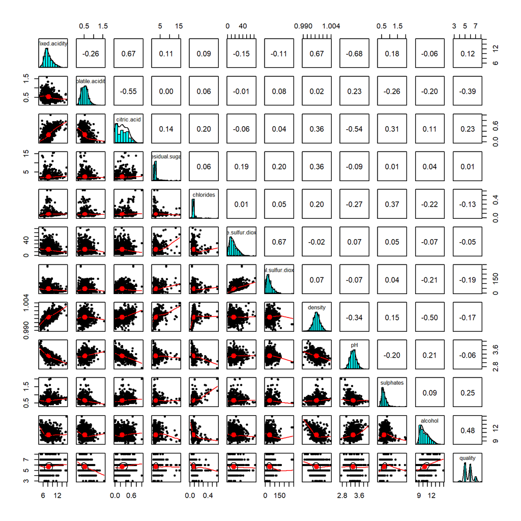

Strongest linear correlations:  
Fixed acidity: great positive correlation with citric acid, density and negative correlation with pH  
Volatile acidity: quite negative correlation with citric acid  
Citric acid: quite negative correlation with pH  
Free sulfur dioxide: great positive correlation with total sulfur dioxide  
Alcohol: some positive correlation with quality.

### Exploring quality with other variables

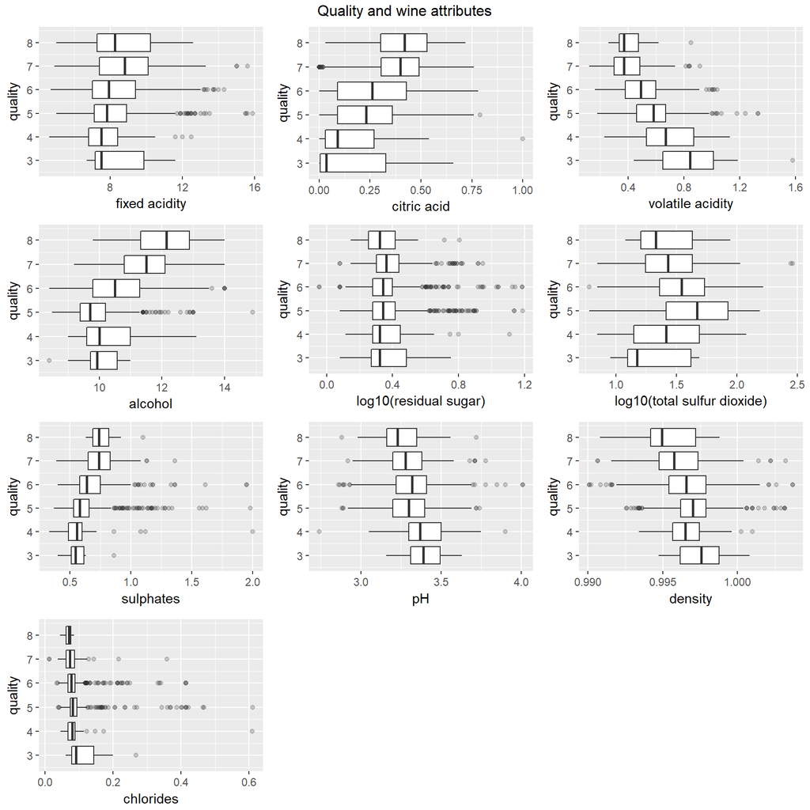

None of characteristics of wine doesn’t have strong influence on quality of wine. It was a surprise for me, I really thought that some of variables will affect quality a lot.

Looking at pair plot and boxplots, we see that quality is positively correlated with fixed and citric acids, sugar, sulphates and alcohol and negatively correlated with volatile acidity, chlorides, sulfur dioxide, density and pH. Variables that affects quality of wine the most:  
1. Alcohol  
2. Volatile acidity  
3. Sulphates  
4. Citric acid

After exploring boxplots, I can single out some trends for good wine quality:  
* more alcohol  
* less volatile acidity  
* more citric acid  
* more sulphates  
* less pH  
* less chlorides  
* density of best wines have lower median than other wine qualities  
* Residual sugar does not seems affect quality of the wines.

### Relationship between other variables

There are some rules regarding wine components, which I would like to check:

#### pH and acidity

“lower the pH, the higher the total acidity in the wine”"

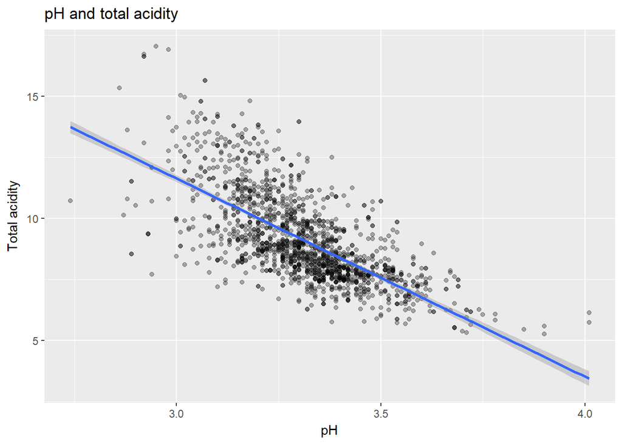

There are more than just 3 acids in wine, but here I used acids I have in dataset. Scatterplot shows that some of acids and pH has a visible negative correlation. Pearson correlation coefficient is -0.68, which indicates a near strong relation.

```
##        cor
## -0.6834838
```

But there is something interesting, fixed acidity and citric acid have negative correlation coefficients: -0.68 and -0.54, but volatile acidity has positive 0.23. It’s a weak correlation, but it should be negative.

#### Alcohol and density

Alcohol level can be measured with wine hydrometer, which measure density. Since density of ethanol is 0.7893 g/cm³, which is lower than water, more alcohol will cured to lower density. That’s why I expect negative relationship between these two variables.

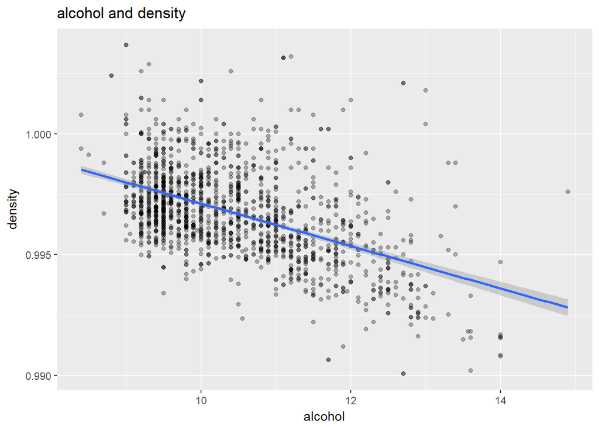

#### Acids and density

Let’s see relationship between acids and density. Density of acids, found in dataset are:  
* Tartaric acid: 1.79 g/cm³  
* Acetic acid: 1.05 g/cm³  
* Citric acid: 1.66 g/cm³

I expect that there will be a positive correlation between all 3 acids and density and that tartaric acid and citric acid will have higher correlations than acetic. Since density of citric acetic acid are almost equals 1 (density of the water).

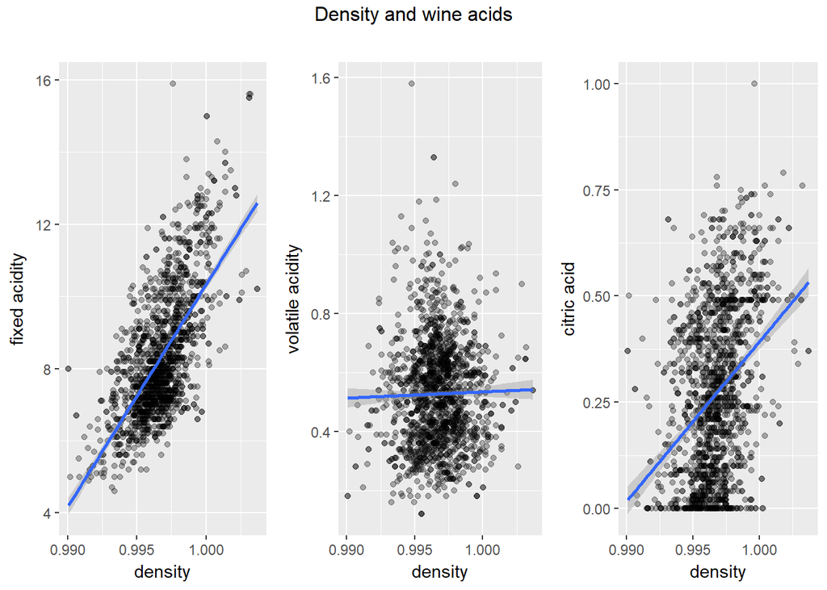

There are other strong correlations from pair plots.

#### Sulfur dioxides

Total sulfur dioxide is a sum of free SO2 and bound SO2.

I want also to look at bound SO2 and see how it correlated to free SO2 and total SO2. If the wine is bottle-aged, the SO2 will decrease as more sulfites react with other chemical constituents (sugars, acetaldehyde or phenolic compounds) in the wine and become bound. Bound sulfur dioxide can be 50 - 90% of the amount of SO2 added to wine.

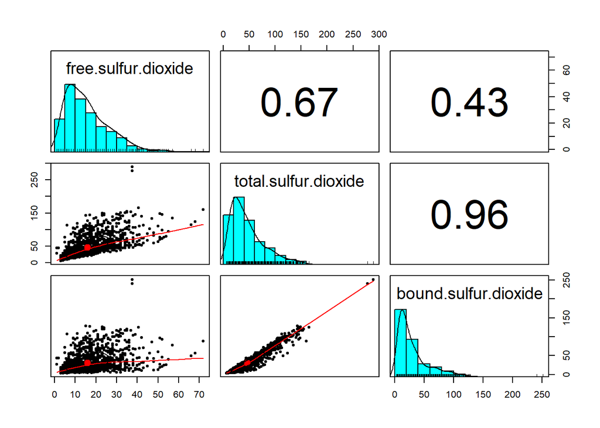

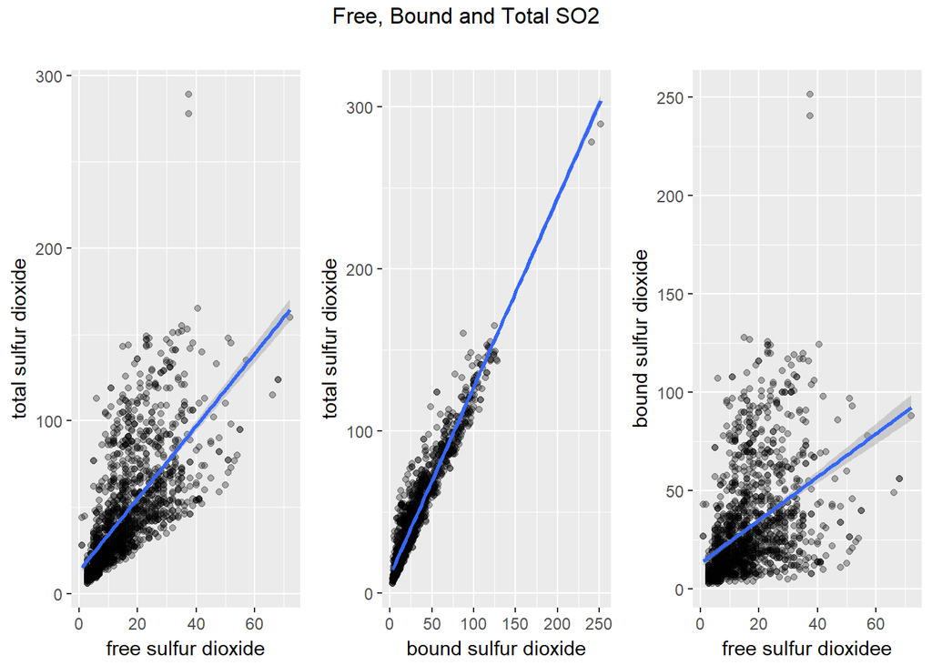

Since both free and bound SO2 are parts of Total SO2, correlation between them and total SO2 are high.

There is a very strong correlation (0.96) between bound and total sulfur dioxides. I think that it is why scatterplots for free SO2 vs total SO2 and free SO2 vs bound SO2 looks very similar.

Correlation between free and bound sulfur dioxide is not so high as expected. Of course, there are a lot of factors affect to what amount of free SO2 will bind.

I wish I had more properties, for example age, so I could analyze how amount of free and bound SO2 depends on wine age.

#### pH and density

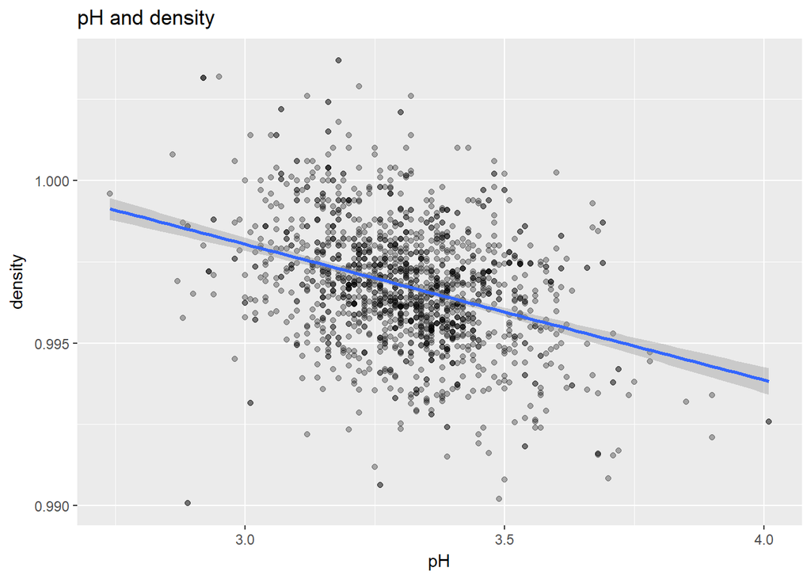

This scatterplot looks very interesting. pH and density of wines from dataset are very concentrated in one sector: where pH is from 3.2 to 3.4 and density is between 0.994 and 0.9975.

Correlation between pH and density are negative and equals -0.34.

#### Acids

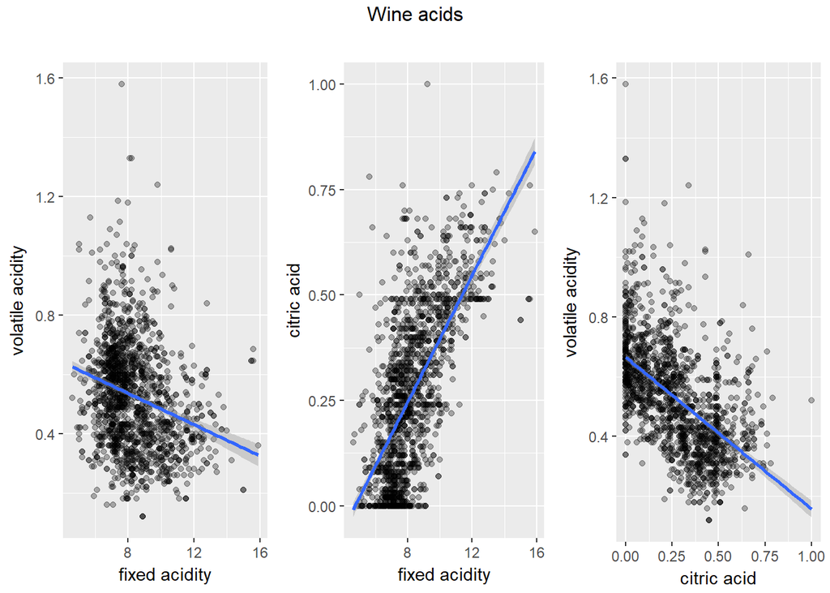

Fixed acidity and citric acid have strong positive correlation. It’s expected since citric acid is a component of tartaric acid. Fixed and volatile acidities, citric acid and volatile acidity have a negative correlation. First pair of acids has a weaker connection than other.

# Bivariate Analysis

### Talk about some of the relationships you observed in this part of the investigation. How did the feature(s) of interest vary with other features in the dataset?

After investigation pairs plot I found 4 variables that affects quality of wine most:  
* Alcohol: wine with more alcohol have better quality  
* Volatile acidity: better quality wines contain less of it. Probably because too high level of it can lead to an unpleasant, vinegar taste.  
* Sulphates  
* Citric acid

Both sulphates and citric acid contains in bigger quantities in good wines. Both correlations is not strong, almost weak. However I don’t think that this 4 variables describes quality of wine so well, because of lack of strong correlations with quality.

### Did you observe any interesting relationships between the other features (not the main feature(s) of interest)?

Interesting for me was relationship between volatile acidity and pH. While acids should have negative correlation coefficient with pH, this acid have it positive.

# Multivariate Plots Section

Let’s see how alcohol and volatile acidity plots against each other and facet by quality.

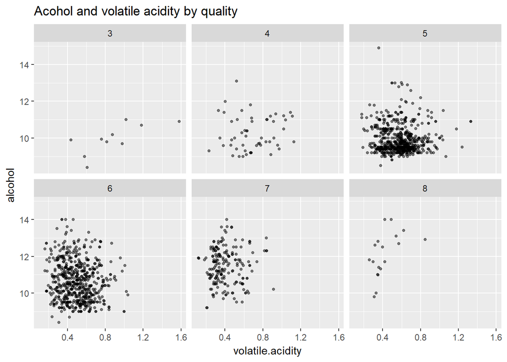

There is a difference between points position on quality above 6 and over. With higher quality positions being more assembled on the left side of scatterplot, which means less volatile acidity, and stretching higher (more alcohol). Wines with quality of 7 and 8 have volatile acidity between 0.2 and 0.6 and alcohol level from 10 and over. While poor quality wines have acidity from 0.4 and above, while alcohol are mostly lower than 11.

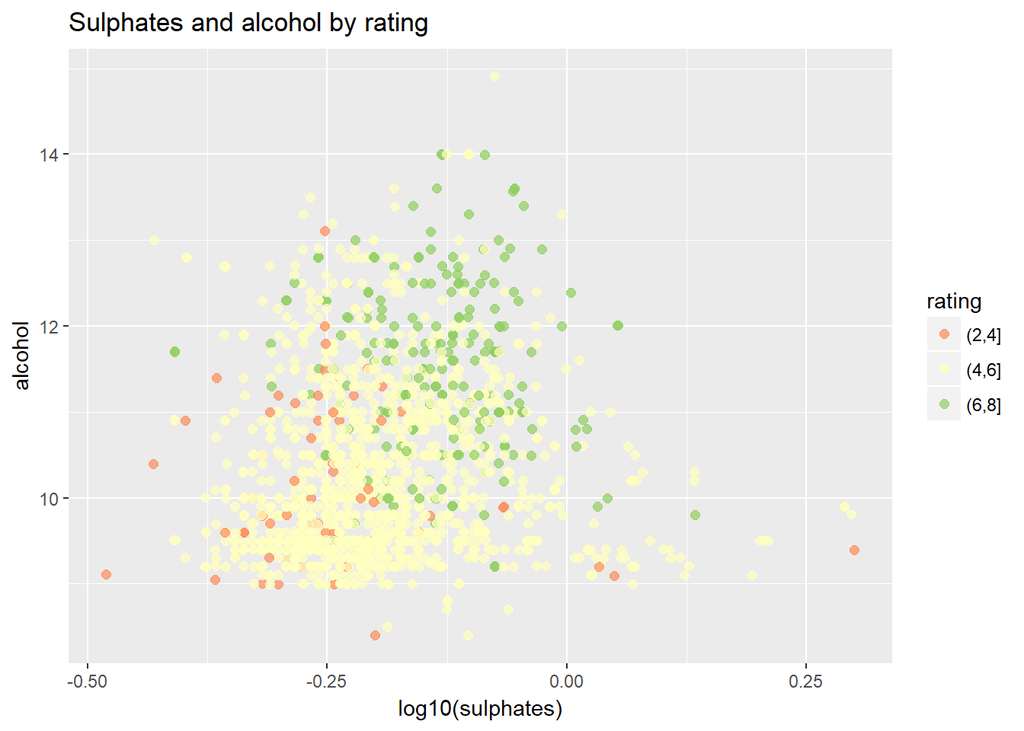

This scatterplot confirms that wines with better quality contains more alcohol and more sulphates.

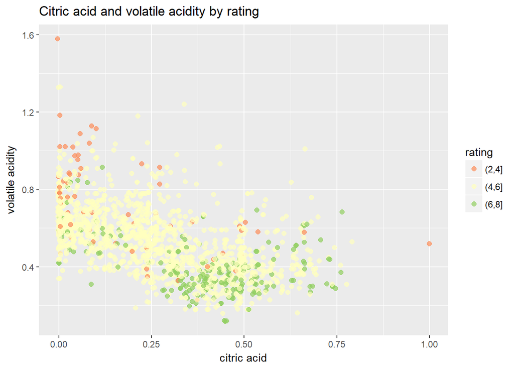

It’s clearly that good wines (with rating of 7 and 8) have lower volatile acidity level most values are lower than 0.6. Citric acids values for poor and good wines are both spread, but it seems that with higher rating amount of citric acids increases.

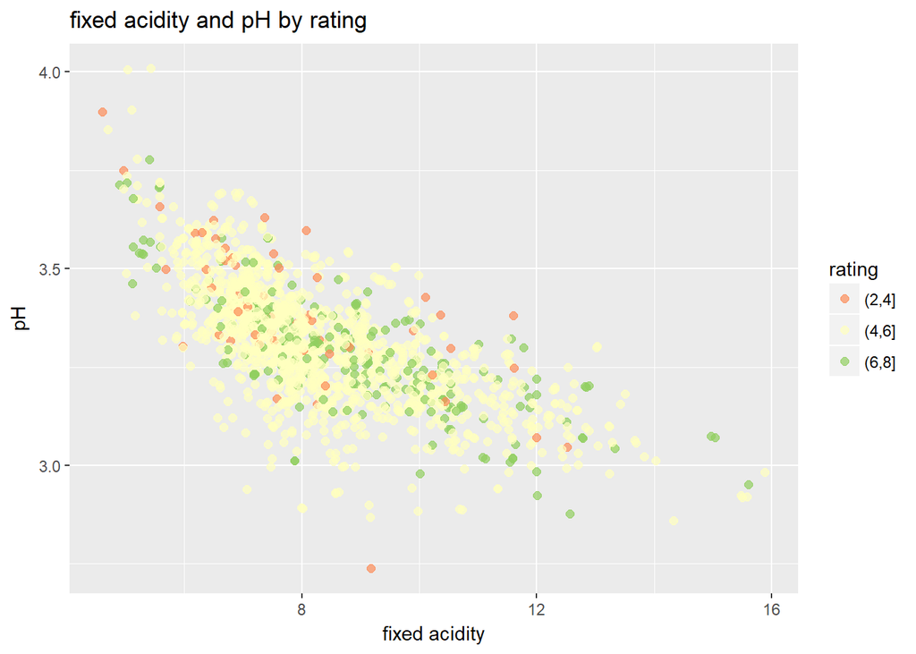

None of pH or fixed acidity has strong correlation with quality. And it can be proved by this plot. Wines with different rating are mixed up and it difficult to find tendency.

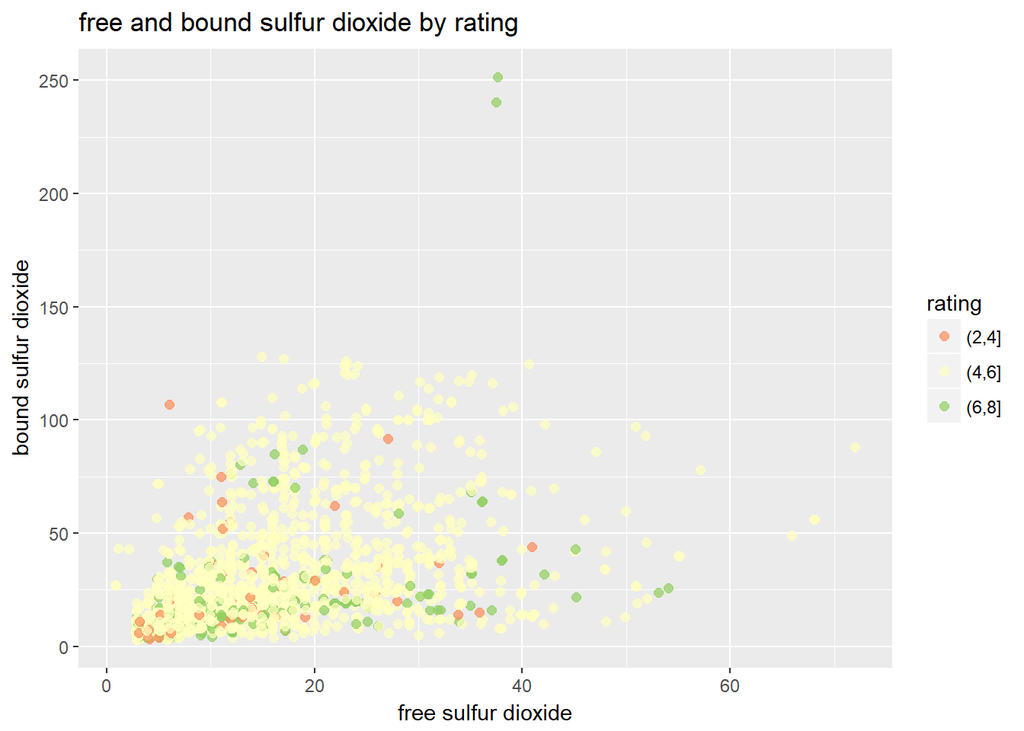

Wines with different qualities have3 almost the same range of free SO2. Most wines with both poor and good (7 and 8 value of quality) have low values of bound SO2. Wine with average quality have higher bound sulfur dioxide.

### Linear model

```
##
## Calls:
## m1: lm(formula = I(quality) ~ I(alcohol), data = redwine)
## m2: lm(formula = I(quality) ~ I(alcohol) + volatile.acidity, data = redwine)
## m3: lm(formula = I(quality) ~ I(alcohol) + volatile.acidity + sulphates,
##     data = redwine)
## m4: lm(formula = I(quality) ~ I(alcohol) + volatile.acidity + sulphates +
##     citric.acid, data = redwine)
##
## ============================================================================
##                          m1            m2            m3            m4
## ----------------------------------------------------------------------------
##   (Intercept)           1.875***      3.095***      2.611***      2.646***
##                        (0.175)       (0.184)       (0.196)       (0.201)
##   I(alcohol)            0.361***      0.314***      0.309***      0.309***
##                        (0.017)       (0.016)       (0.016)       (0.016)
##   volatile.acidity                   -1.384***     -1.221***     -1.265***
##                                      (0.095)       (0.097)       (0.113)
##   sulphates                                         0.679***      0.696***
##                                                    (0.101)       (0.103)
##   citric.acid                                                    -0.079
##                                                                  (0.104)
## ----------------------------------------------------------------------------
##   R-squared             0.227         0.317         0.336         0.336
##   adj. R-squared        0.226         0.316         0.335         0.334
##   sigma                 0.710         0.668         0.659         0.659
##   F                   468.267       370.379       268.912       201.777
##   p                     0.000         0.000         0.000         0.000
##   Log-likelihood    -1721.057     -1621.814     -1599.384     -1599.093
##   Deviance            805.870       711.796       692.105       691.852
##   AIC                3448.114      3251.628      3208.768      3210.186
##   BIC                3464.245      3273.136      3235.654      3242.448
##   N                  1599          1599          1599          1599
## ============================================================================
```

Based on the R-squared value, 4 selected variables explains about 33.6 percent of the variance in quality. It’s not much. And like I see here, citric acid don’t affect results.

# Multivariate Analysis

### Talk about some of the relationships you observed in this part of the investigation. Were there features that strengthened each other in terms of looking at your feature(s) of interest?

After investigating multivariate plots I can make a conclusion about some combinations that give high wine quality:  
* Low volatile acidity and high alcohol level  
* High sulphate and alcohol rate  
* Low volatile acidity and high citric acid  
* Low bound sulfur dioxide

### Were there any interesting or surprising interactions between features?

It was interesting to see multivariate plot of free and bound SO2. Most wines with poor and high rating had almost same bound SO2 level. There were also 2 outliers that had very high, compared to others, bound SO2 rate (about 250 mg/dm³). Interesting thing was that both wines had same free SO2 value (37.5 mg/dm³ ) and good rating (7 or 8 in quality).

### OPTIONAL: Did you create any models with your dataset? Discuss the strengths and limitations of your model.

I calculated a linear model, but it shows that those 4 wine attributes that were correlated most with wine quality explains just 33.6% of variability in quality. In addition to that, last attribute, which is citric acid were statistically insignificant.

# Final Plots and Summary

### Plot One

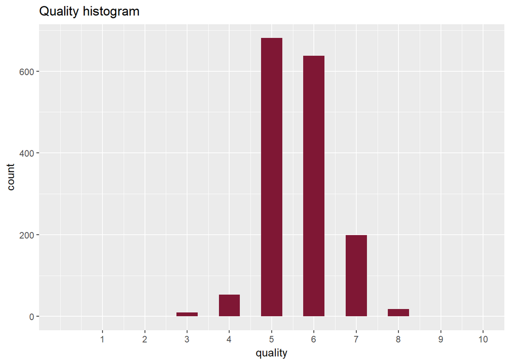

```
##
##    3    4    5    6    7    8
## 0.01 0.03 0.43 0.40 0.12 0.01
```

### Description One

Experts graded the wine quality between 0 (very bad) and 10 (very excellent). But no wine in dataset have got worst or best grades. Minimum grade is 3 and maximum is 8. 83% of wines have wine quality of 5 or 6. While wine with better quality only 13% and with worse only 4%. It can make it difficult to analyze wines. If quality dataset have had more uniform distribution it could give a stronger comparison between good and bad wines.

### Plot Two

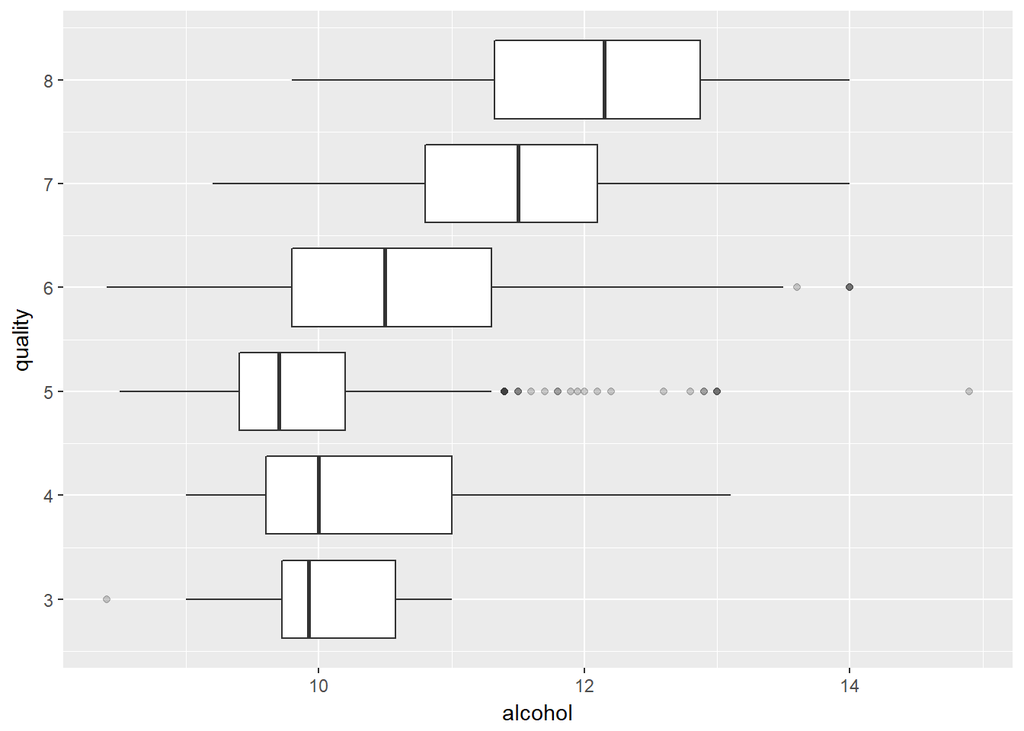

### Description Two

Red wine quality have strongest correlation with alcohol and it equals 0.48. This boxplot shows that quality of wine increases same as amount of alcohol increases. So next time you will buy a bottle of red wine, take one with higher alcohol %.

### Plot Three

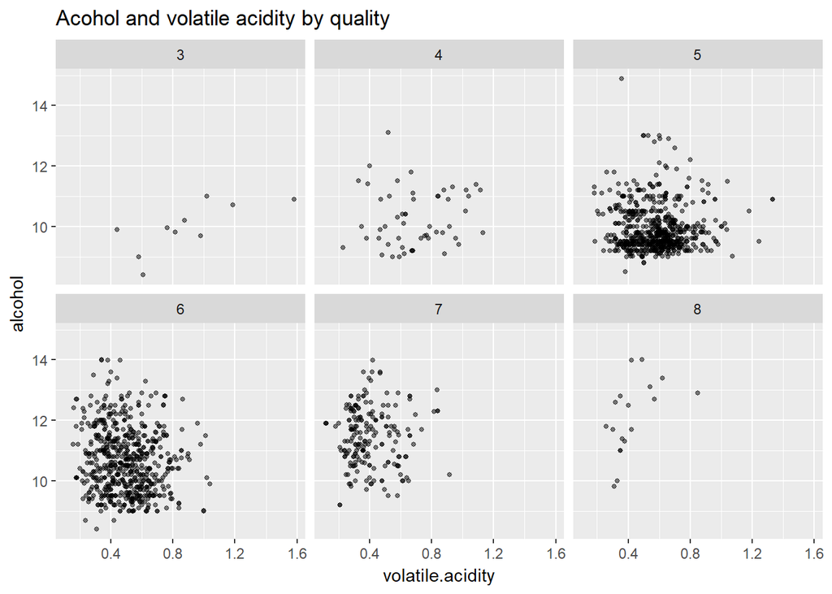

### Description Three

Red wine quality affects most by alcohol and volatile acidity. Here I facet it by wine quality. High alcohol amount and low volatile acidity provides better wines.

# Reflection

I don’t drink alcohol, so I though this analysis can help me to get learn something about wines and expand my knowledge area.  
I was excited to start analysis and find about which one (or may be more) attributes affects wine quality.

Dataset I analyzed contains 1599 wine samples with 12 attributes. One of them is quality, graded by experts. I started with univariate analysis (analysis of each attribute) using histogram plots, looking to distributions. I met a little difficulty because I knew nothing about wines, so I spend a lot of time on this stage, reading articles about wines characteristics and finding information about each attributes, like what values are normal and how high values of attributes affects taste of wine.

After that I started a bivariate analysis. Pairs plot helped me to see all correlations between variables. I used it as basis for the rest of analysis. I used box plots and scatterplots to see how 2 variables are related to each other. Of course I was focused more on relations with wine quality. But when I analyzed other variables I felt that I’m missing some chemistry knowledge to understand why variables are correlated. This stage helped me to get closer to the answer of main question.

Next step was multivariate analysis, it clarified my findings by use of colored scatterplots. On this stage I also calculated a linear model for 4 most correlated to quality attributes.

Highest correlation with quality I’ve got was 0.48 and I am not satisfied with a linear model I’ve got. There was one more difficulty I met between this stage and nest stage is trying to understand what wine “quality” means. What criteria experts have used during wine grading? Was is just taste score or not? Also, I really wish I could have more attributes to analyze, like wine age, price, region, grape type. All these could help to build more precise linear model, which I could use to determine what bottle of red wine, I’ve got some present, I should keep to myself and what I can give away;)